# Wine Quality Predictor

# Dependencies

```r
library(dplyr)
library(knitr)
library(tibble)
library(CORElearn)
library(ggplot2)
library(corrplot)
library(rpart)
library(rpart.plot)
library(caret)
library(e1071)
```

# Reading Dataset

**White Wine dataset**

```r
whiteWineURL <- "https://archive.ics.uci.edu/ml/machine-learning-databases/wine-quality/winequality-white.csv"

whiteRawData <- read.csv(whiteWineURL, header = TRUE, sep = ";")
```

**Red Wine dataset**

```r
redWineURL <- "https://archive.ics.uci.edu/ml/machine-learning-databases/wine-quality/winequality-red.csv"

redRawData <- read.csv(redWineURL, header = TRUE, sep = ";")
```

Add Color attribute

```r
redRawData['color'] <- 'red.wine'
whiteRawData['color'] <- 'white.wine'
```

Number of samples in raw data

```r
nrow(redRawData)
```

```
[1] 1599
```

```r
nrow(whiteRawData)
```

```
[1] 4898
```

## Unknown Values

Datasets have no unknown values

```r
any(is.na(whiteRawData))
```

```
[1] FALSE
```

```r
any(is.na(redRawData))
```

```
[1] FALSE
```

## Duplicated Samples

There are duplicated samples in both of the datasets

```r
any(duplicated(whiteRawData))
```

```
[1] TRUE
```

```r
any(duplicated(redRawData))
```

```
[1] TRUE
```

Remove duplicated data

```r
whiteRawData <- whiteRawData[!duplicated(whiteRawData),]
redRawData <- redRawData[!duplicated(redRawData),]
```

Number of samples are reduced

```r
nrow(redRawData)
```

```
[1] 1359
```

```r
nrow(whiteRawData)
```

```
[1] 3961
```

## Attribute Overview

Quality value ranges from 3 to 9 in white wine dataset.

```r
unique(whiteRawData$quality)
```

```
[1] 6 5 7 8 4 3 9
```

On the other hand quality in red wine dataset ranges from 3 to 8.

```r
unique(redRawData$quality)
```

```
[1] 5 6 7 4 8 3
```

If we look at any dataset, quality values are integer. This causes trouble in R functions when evaluating quality and other attributes together.

```r
kable(sapply(whiteRawData, class))
```

|  | x |
| --- | --- |
| fixed.acidity | numeric |
| volatile.acidity | numeric |
| citric.acid | numeric |
| residual.sugar | numeric |
| chlorides | numeric |
| free.sulfur.dioxide | numeric |
| total.sulfur.dioxide | numeric |
| density | numeric |
| pH | numeric |
| sulphates | numeric |
| alcohol | numeric |
| quality | integer |
| color | character |

We can cast quality values to numeric.

```r
whiteRawData$quality <- as.numeric(whiteRawData$quality)
redRawData$quality <- as.numeric(redRawData$quality)
```

```r
mergedRawData <- rbind(whiteRawData, redRawData)
```

Quality values can be categorized as “Poor”, “Normal” and “Good”.

```r
whiteData <- whiteRawData
whiteData$quality <- cut(whiteData$quality,
                          breaks=c(3, 5, 6, Inf),
                          labels=c("Poor", "Normal", "Good"),
                          include.lowest = TRUE)
```

```r
redData <- redRawData
redData$quality <- cut(redData$quality,
                      breaks=c(3, 5, 6, Inf),
                      labels=c("Poor", "Normal", "Good"),
                      include.lowest = TRUE)
```

Merged dataset

```r
mergedData <- rbind(whiteData, redData)
```

# Explotary Data Analysis

## Custom Functions

```r
histogramPlot <- function(data, attribute, binWidth, xLabel, title)
{
   ggplot(data, aes(x=attribute, fill = quality)) +
    geom_histogram(binwidth = binWidth, color="black", fill="steelblue", linetype="dashed") +
    ggtitle(title) +
    labs(x = xLabel, y = "Count") +
    facet_wrap( ~quality) +
    theme(plot.title = element_text(hjust = 0.5))
}
```

```r
histogramByLogScalePlot <- function(data, attribute, binWidth, xLabel, title)
{
  ggplot(data, aes(x=attribute)) +
    geom_histogram(binwidth = binWidth, color="black", fill="steelblue", linetype="dashed") +
    scale_x_log10()+
    ggtitle(title) +
    labs(x = xLabel, y = "Count") +
    facet_wrap( ~color) +
    theme(plot.title = element_text(hjust = 0.5))

}
```

```r
attibutesOverQualityBoxplot <- function (attribute, title)
{
  ggplot(mergedData, aes(x = factor(quality), y = attribute)) +
    stat_boxplot(geom ='errorbar') +
    labs(x = "Quality", y = "Value") +
    ggtitle(title) +
    geom_boxplot(outlier.colour = "red", outlier.shape = 1,  colour = "blue") +
    geom_jitter(size = 1.5, alpha = 0.1)  +
    theme(plot.title = element_text(hjust = 0.5)) +
    facet_wrap(~color)
}
```

## Quality

Number of Samples according to numeric qualities.

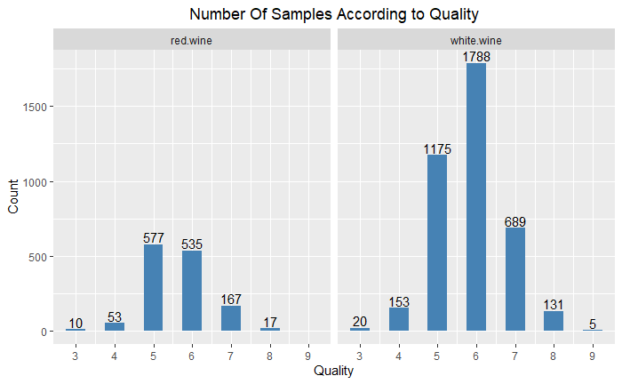

```r
ggplot(data = mergedRawData, aes(x = quality)) +
  geom_bar(fill="steelblue", width=0.5) +
  ggtitle("Number Of Samples According to Quality") +
  labs(x = "Quality", y = "Count") +
  geom_text(stat = 'count',aes(label =..count.., vjust = -0.2)) +
  facet_wrap( ~color) +
  theme(plot.title = element_text(hjust = 0.5)) +
  scale_x_continuous(breaks = unique(mergedRawData$quality))
```

Number of Samples according to categorical qualities.

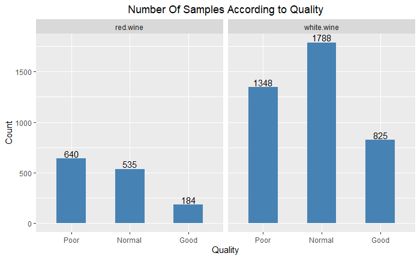

```r
ggplot(data = mergedData, aes(x = quality)) +
  geom_bar(fill="steelblue", width=0.5) +
  ggtitle("Number Of Samples According to Quality") +
  labs(x = "Quality", y = "Count") +
  geom_text(stat = 'count',aes(label =..count.., vjust = -0.2)) +
  facet_wrap( ~color) +
  theme(plot.title = element_text(hjust = 0.5))
```

## Fixed Acidity

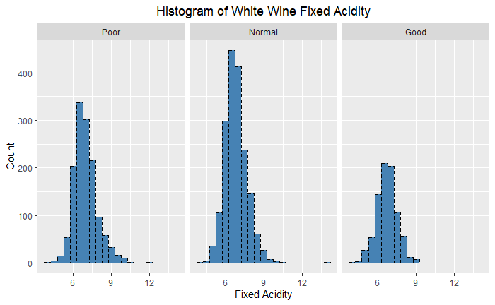

```r
histogramPlot(whiteData, whiteData$fixed.acidity, 0.5,
              "Fixed Acidity", "Histogram of White Wine Fixed Acidity")
```

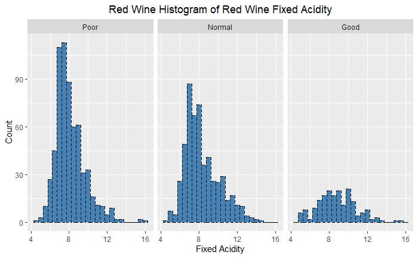

```r
histogramPlot(redData, redData$fixed.acidity, 0.5,
              "Fixed Acidity", "Red Wine Histogram of Red Wine Fixed Acidity")
```

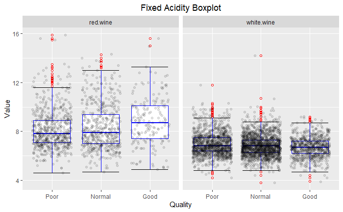

```r
attibutesOverQualityBoxplot(mergedData$fixed.acidity, "Fixed Acidity Boxplot")
```

```r
redData %>%
  select(fixed.acidity) %>%
  summarise_all(list(md = median, mn = mean, sd = sd, IQR = IQR)) %>% kable
```

| md | mn | sd | IQR |
| --- | --- | --- | --- |
| 7.9 | 8.310596 | 1.73699 | 2.1 |

```r
whiteData %>%
  select(fixed.acidity) %>%
  summarise_all(list(md = median, mn = mean, sd = sd, IQR = IQR)) %>% kable
```

| md | mn | sd | IQR |
| --- | --- | --- | --- |
| 6.8 | 6.839346 | 0.8668597 | 1 |

## Volatile Acidity

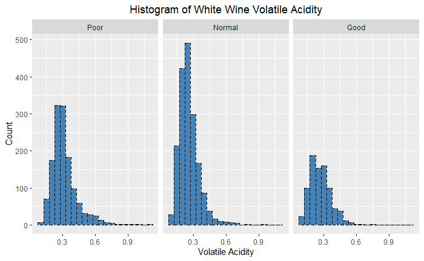

```r
histogramPlot(whiteData, whiteData$volatile.acidity, 0.05,
              "Volatile Acidity", "Histogram of White Wine Volatile Acidity")
```

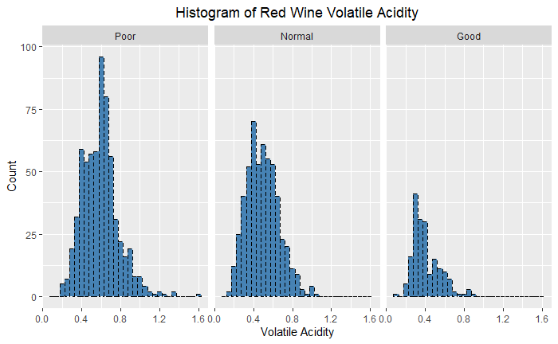

```r
histogramPlot(redData, redData$volatile.acidity, 0.05,
              "Volatile Acidity", "Histogram of Red Wine Volatile Acidity")
```

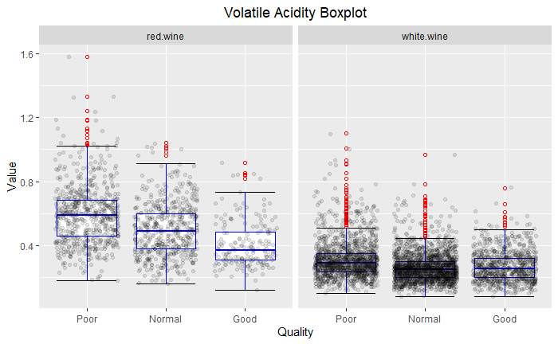

```r
attibutesOverQualityBoxplot(mergedData$volatile.acidity, "Volatile Acidity Boxplot")
```

```r
redData %>%
  select(volatile.acidity) %>%
  summarise_all(list(md = median, mn = mean, sd = sd, IQR = IQR)) %>% kable
```

| md | mn | sd | IQR |
| --- | --- | --- | --- |
| 0.52 | 0.5294776 | 0.1830313 | 0.25 |

```r
whiteData %>%
  select(volatile.acidity) %>%
  summarise_all(list(md = median, mn = mean, sd = sd, IQR = IQR)) %>% kable
```

| md | mn | sd | IQR |
| --- | --- | --- | --- |
| 0.26 | 0.2805377 | 0.1034371 | 0.12 |

## Citric Acid

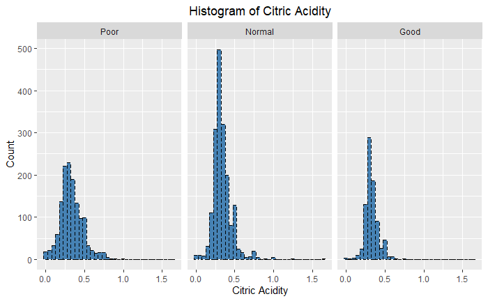

```r
histogramPlot(whiteData, whiteData$citric.acid, 0.05, "Citric Acidity", "Histogram of Citric Acidity")
```

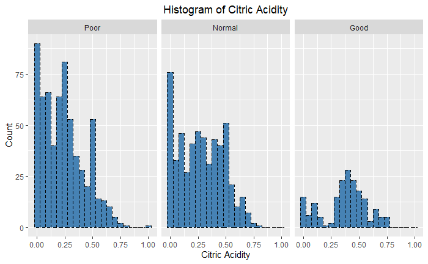

```r
histogramPlot(redData, redData$citric.acid, 0.05, "Citric Acidity", "Histogram of Citric Acidity")
```

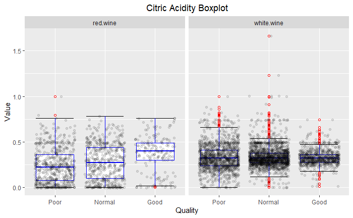

```r
attibutesOverQualityBoxplot(mergedData$citric.acid, "Citric Acidity Boxplot")
```

```r
redData %>%
  select(citric.acid) %>%
  summarise_all(list(md = median, mn = mean, sd = sd, IQR = IQR)) %>% kable
```

| md | mn | sd | IQR |
| --- | --- | --- | --- |
| 0.26 | 0.2723326 | 0.1955365 | 0.34 |

```r
whiteData %>%
  select(citric.acid) %>%
  summarise_all(list(md = median, mn = mean, sd = sd, IQR = IQR)) %>% kable
```

| md | mn | sd | IQR |
| --- | --- | --- | --- |
| 0.32 | 0.3343322 | 0.1224461 | 0.12 |

## Residual Sugar

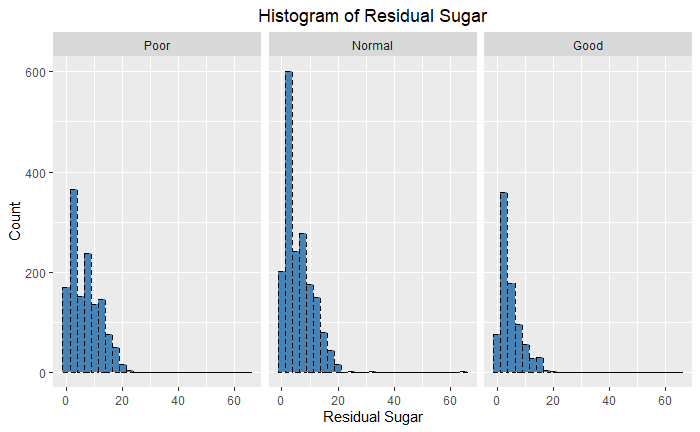

```r
histogramPlot(whiteData, whiteData$residual.sugar, 2.5, "Residual Sugar","Histogram of Residual Sugar")
```

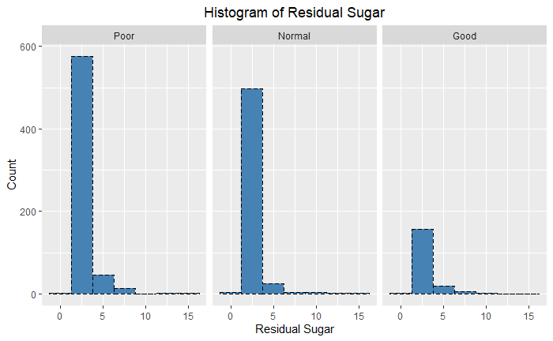

```r
histogramPlot(redData, redData$residual.sugar, 2.5, "Residual Sugar","Histogram of Residual Sugar")
```

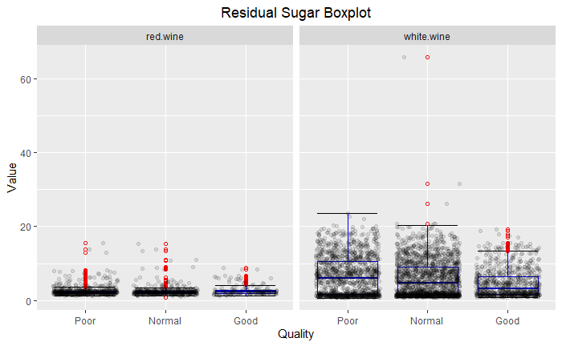

```r
attibutesOverQualityBoxplot(mergedData$residual.sugar, "Residual Sugar Boxplot")
```

```r
redData %>%
  select(residual.sugar) %>%
  summarise_all(list(md = median, mn = mean, sd = sd, IQR = IQR)) %>% kable
```

| md | mn | sd | IQR |
| --- | --- | --- | --- |
| 2.2 | 2.5234 | 1.352314 | 0.7 |

```r
whiteData %>%
  select(residual.sugar) %>%
  summarise_all(list(md = median, mn = mean, sd = sd, IQR = IQR)) %>% kable
```

| md | mn | sd | IQR |
| --- | --- | --- | --- |
| 4.7 | 5.91482 | 4.861646 | 7.3 |

## Chlorides

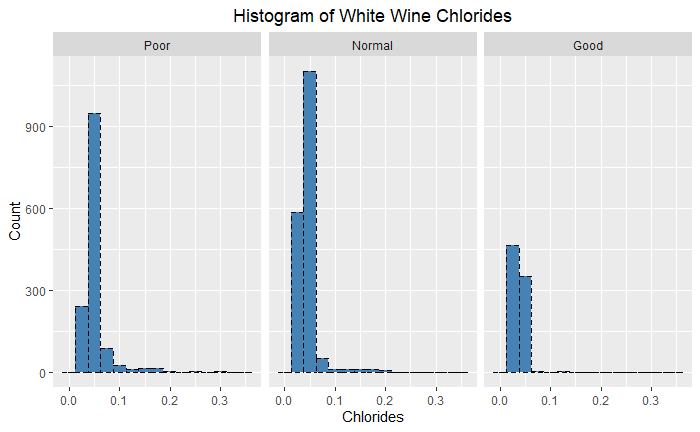

```r
histogramPlot(whiteData, whiteData$chlorides, 0.025,
              "Chlorides", "Histogram of White Wine Chlorides")
```

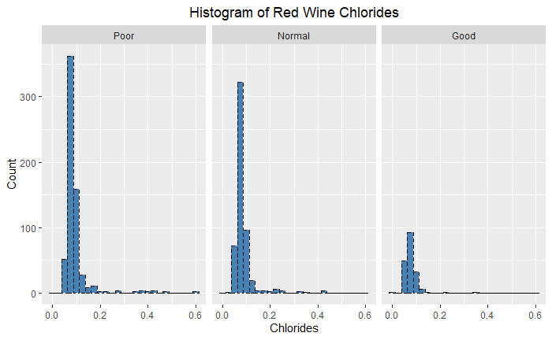

```r
histogramPlot(redData, redData$chlorides, 0.025,
              "Chlorides", "Histogram of Red Wine Chlorides")
```

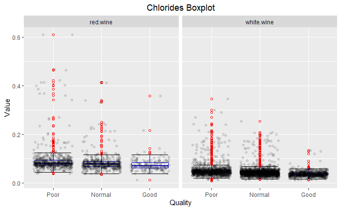

```r
attibutesOverQualityBoxplot(mergedData$chlorides, "Chlorides Boxplot")
```

```r
redData %>%
  select(chlorides) %>%
  summarise_all(list(md = median, mn = mean, sd = sd, IQR = IQR)) %>% kable
```

| md | mn | sd | IQR |
| --- | --- | --- | --- |
| 0.079 | 0.0881236 | 0.0493769 | 0.021 |

```r
whiteData %>%
  select(chlorides) %>%
  summarise_all(list(md = median, mn = mean, sd = sd, IQR = IQR)) %>% kable
```

| md | mn | sd | IQR |
| --- | --- | --- | --- |
| 0.042 | 0.0459051 | 0.0231027 | 0.015 |

## Free Sulfur Dioxide

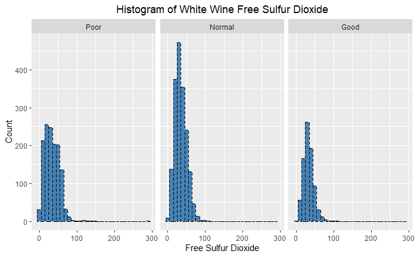

```r
histogramPlot(whiteData, whiteData$free.sulfur.dioxide, 10.0,
              "Free Sulfur Dioxide","Histogram of White Wine Free Sulfur Dioxide")
```

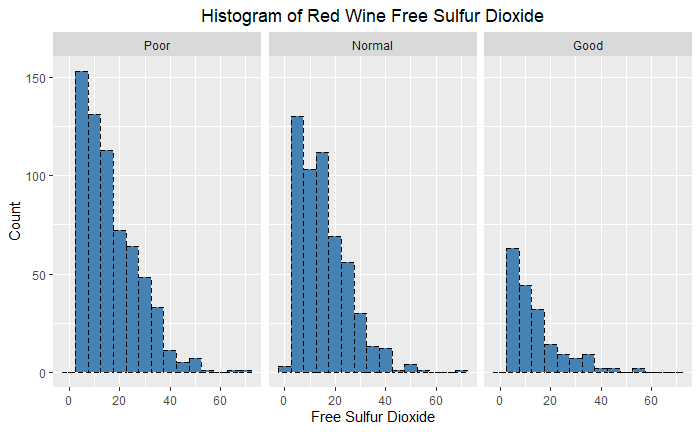

```r
histogramPlot(redData, redData$free.sulfur.dioxide, 5.0,
              "Free Sulfur Dioxide","Histogram of Red Wine Free Sulfur Dioxide")
```

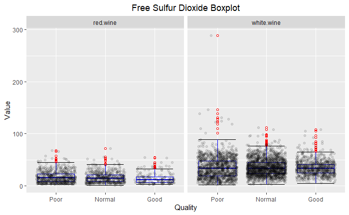

```r
attibutesOverQualityBoxplot(mergedData$free.sulfur.dioxide, "Free Sulfur Dioxide Boxplot")
```

```r
redData %>%
  select(free.sulfur.dioxide) %>%
  summarise_all(list(md = median, mn = mean, sd = sd, IQR = IQR)) %>% kable
```

| md | mn | sd | IQR |
| --- | --- | --- | --- |
| 14 | 15.8933 | 10.44727 | 14 |

```r
whiteData %>%
  select(free.sulfur.dioxide) %>%
  summarise_all(list(md = median, mn = mean, sd = sd, IQR = IQR)) %>% kable
```

| md | mn | sd | IQR |
| --- | --- | --- | --- |
| 33 | 34.88917 | 17.21002 | 22 |

## Total Sulfur Dioxide

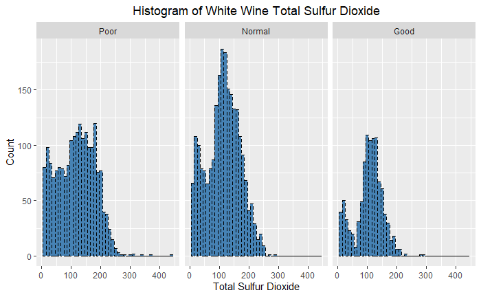

```r
histogramPlot(mergedData, mergedData$total.sulfur.dioxide, 10.0,
              "Total Sulfur Dioxide", "Histogram of White Wine Total Sulfur Dioxide")
```

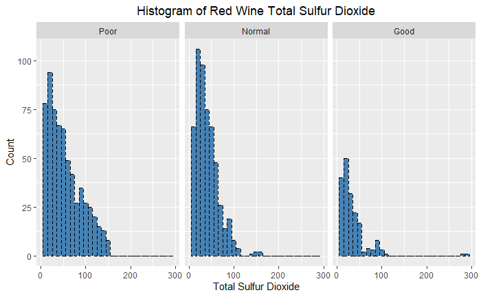

```r
histogramPlot(redData, redData$total.sulfur.dioxide, 10.0,
              "Total Sulfur Dioxide", "Histogram of Red Wine Total Sulfur Dioxide")
```

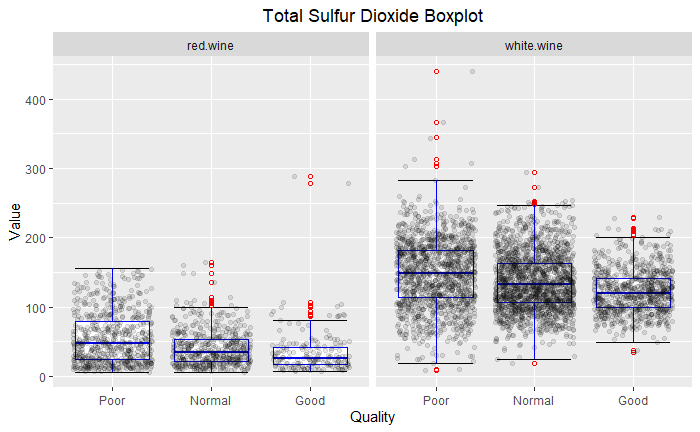

```r
attibutesOverQualityBoxplot(mergedData$total.sulfur.dioxide, "Total Sulfur Dioxide Boxplot")
```

```r
redData %>%
  select(total.sulfur.dioxide) %>%
  summarise_all(list(md = median, mn = mean, sd = sd, IQR = IQR)) %>% kable
```

| md | mn | sd | IQR |
| --- | --- | --- | --- |
| 38 | 46.82597 | 33.40895 | 41 |

```r
whiteData %>%
  select(total.sulfur.dioxide) %>%
  summarise_all(list(md = median, mn = mean, sd = sd, IQR = IQR)) %>% kable
```

| md | mn | sd | IQR |
| --- | --- | --- | --- |
| 133 | 137.1935 | 43.12907 | 60 |

## Density

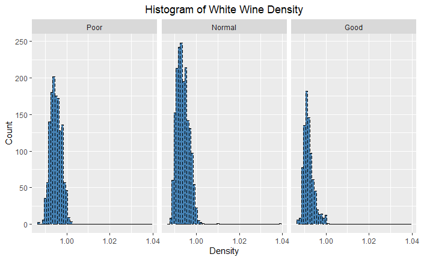

```r
histogramPlot(whiteData, whiteData$density, 0.001,
              "Density", "Histogram of White Wine Density")
```

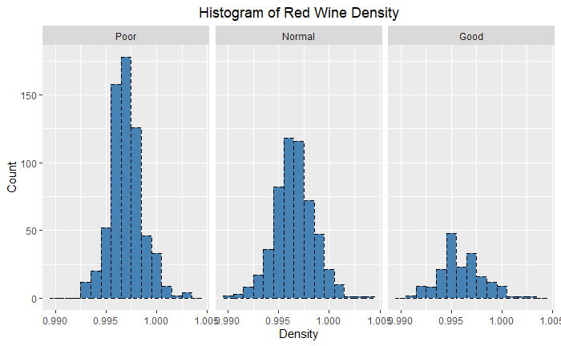

```r
histogramPlot(redData, redData$density, 0.001,
              "Density", "Histogram of Red Wine Density")
```

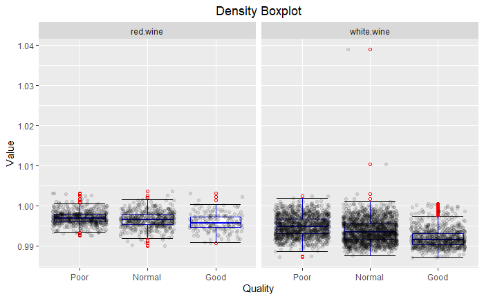

```r
attibutesOverQualityBoxplot(mergedData$density, "Density Boxplot")
```

```r
redData %>%
  select(density) %>%
  summarise_all(list(md = median, mn = mean, sd = sd, IQR = IQR)) %>% kable
```

| md | mn | sd | IQR |
| --- | --- | --- | --- |
| 0.9967 | 0.9967089 | 0.0018689 | 0.00222 |

```r
whiteData %>%
  select(density) %>%
  summarise_all(list(md = median, mn = mean, sd = sd, IQR = IQR)) %>% kable
```

| md | mn | sd | IQR |
| --- | --- | --- | --- |
| 0.9935 | 0.9937895 | 0.0029046 | 0.00409 |

## pH

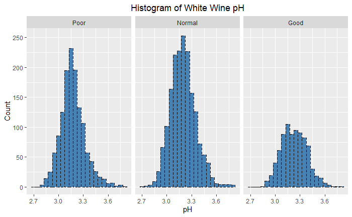

```r
histogramPlot(whiteData, whiteData$pH, 0.05, "pH","Histogram of White Wine pH")
```

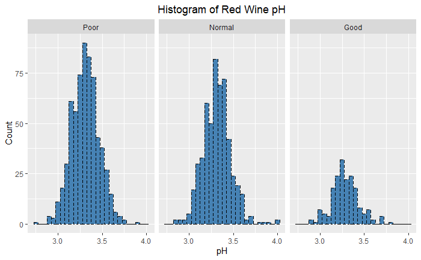

```r
histogramPlot(redData, redData$pH, 0.05, "pH","Histogram of Red Wine pH")
```

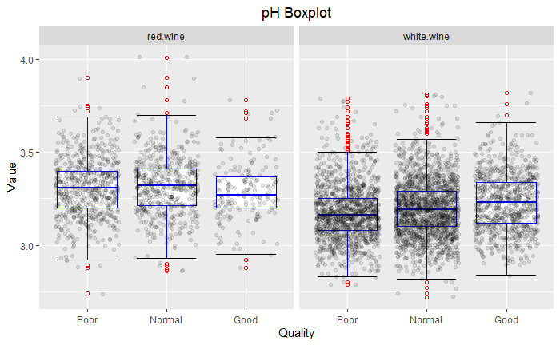

```r
attibutesOverQualityBoxplot(mergedData$pH, "pH Boxplot")
```

```r
redData %>%
  select(pH) %>%
  summarise_all(list(md = median, mn = mean, sd = sd, IQR = IQR)) %>% kable
```

| md | mn | sd | IQR |
| --- | --- | --- | --- |
| 3.31 | 3.309787 | 0.1550363 | 0.19 |

```r
whiteData %>%
  select(pH) %>%
  summarise_all(list(md = median, mn = mean, sd = sd, IQR = IQR)) %>% kable
```

| md | mn | sd | IQR |
| --- | --- | --- | --- |
| 3.18 | 3.195458 | 0.1515456 | 0.2 |